# CustomerLens-Analytics

Dime con quién vives y te diré qué compras

Jaime Linares, Andrés Martínez, Pablo Oliva y Francisco Javier Ruiz | Grupo 2

## Contextualización y motivación

Comprender cómo la estructura familiar influye en el comportamiento de compra es una de las preguntas más relevantes en *Customer Analytics* para maximizar el **CLV (Customer Lifetime Value)** y optimizar el Retorno de Inversión (ROI) en las campañas. En un contexto de distribución generalista, los hogares con hijos suelen gastar más en alimentación básica, pero no necesariamente a través de cualquier canal ni en gamas altas. La clave está en alinear el catálogo con el **modelo de negocio**.

En este notebook nos planteamos la siguiente pregunta core de negocio:

**¿Hay relación entre la estructura familiar del cliente y su patrón de consumo?**

A partir de la pregunta principal se derivan las siguientes subpreguntas:

- ¿Los hogares con hijos gastan menos en total que los hogares sin hijos?
- ¿Cambia la distribución del gasto por categoría de producto según la presencia de hijos?
- ¿Influye el número de menores en el hogar en el gasto total y por tipo de producto?
- ¿Existe relación entre el estado civil del cliente y su patrón de consumo?
- ¿Qué variables de estructura familiar son las más determinantes para predecir el nivel de gasto de un cliente?

## Carga de librerías y datos

Cargamos las librerías necesarias y el dataset ya preprocesado en el notebook anterior (`1_preprocesamiento.Rmd`).

```r
library(dplyr)
library(readr)
library(ggplot2)
library(tidyr)
library(scales)
library(rpart)
library(rpart.plot)
library(plotly)
```

```r
data <- read_csv("./data/marketing_campaign_processed.csv", show_col_types = FALSE)

# Convertimos las variables categóricas a factor
data$Education <- factor(data$Education,
    levels = c("Basic", "2n Cycle", "Graduation", "Master", "PhD"),
    ordered = TRUE
)
data$Marital_Status <- factor(data$Marital_Status,
    levels = c("Single", "Together", "Married", "Divorced", "Widow")
)
data$Has_Children <- factor(data$Has_Children, levels = c(0, 1), labels = c("Sin hijos", "Con hijos"))
data$Children_Home <- factor(data$Children_Home)
```

Definimos una paleta de colores coherente que utilizaremos a lo largo de todo el análisis:

```r
palette_main <- c("Sin hijos" = "#2E86AB", "Con hijos" = "#E8505B")
palette_products <- c(
    "Vino" = "#722F37", "Fruta" = "#7CB518", "Carne" = "#D4453B",
    "Pescado" = "#1B98E0", "Dulces" = "#F4A261", "Oro" = "#E9C46A"
)
palette_children <- c("0" = "#2E86AB", "1" = "#F4A261", "2" = "#E8505B", "3" = "#6B4226")
```

## Análisis 1: Gasto total según presencia de hijos

### 1.1. Exploración descriptiva

Comenzamos comparando el gasto total entre hogares con y sin hijos.

```r
stats_hijos <- data %>%
    group_by(Has_Children) %>%
    summarise(
        n = n(),
        media = mean(Total_Spending),
        mediana = median(Total_Spending),
        desv_tip = sd(Total_Spending),
        Q1 = quantile(Total_Spending, 0.25),
        Q3 = quantile(Total_Spending, 0.75),
        .groups = "drop"
    )
stats_hijos
```

```
## # A tibble: 2 x 7
##   Has_Children     n media mediana desv_tip    Q1    Q3
##   <fct>        <int> <dbl>   <dbl>    <dbl> <dbl> <dbl>
## 1 Sin hijos      625 1112.    1192     642.   653  1597
## 2 Con hijos     1577  409.     198     451.    55   662
```

### 1.2. Visualización: distribución del gasto total

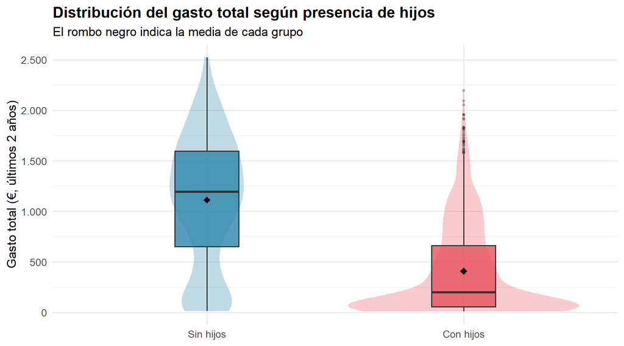

```r
ggplot(data, aes(x = Has_Children, y = Total_Spending, fill = Has_Children)) +
    geom_violin(alpha = 0.3, color = NA) +
    geom_boxplot(width = 0.25, alpha = 0.8, outlier.alpha = 0.3, outlier.size = 1) +
    stat_summary(fun = mean, geom = "point", shape = 18, size = 3, color = "black") +
    scale_fill_manual(values = palette_main) +
    scale_y_continuous(labels = comma_format(big.mark = ".", decimal.mark = ",")) +
    labs(
        title = "Distribución del gasto total según presencia de hijos",
        subtitle = "El rombo negro indica la media de cada grupo",
        x = NULL, y = "Gasto total (€, últimos 2 años)"
    ) +
    theme_minimal(base_size = 13) +
    theme(
        legend.position = "none",
        plot.title = element_text(face = "bold")
    )
```

**Interpretación:** En este gráfico de violín superpuesto con diagrama de caja, observamos claramente cómo la distribución del grupo “Sin hijos” se sitúa muy por encima de la del grupo “Con hijos”. El rombo negro (la media) del grupo sin hijos frente a el de los hogares con menores, marcan una brecha de consumo evidente a primera vista.

### 1.3. Test estadístico: Wilcoxon

Dado que la distribución del gasto total presenta asimetría y valores atípicos, utilizamos el **test de Wilcoxon** (test no paramétrico equivalente al *t*-test), que no asume normalidad y es robusto frente a distribuciones sesgadas.

```r
wilcox_total <- wilcox.test(Total_Spending ~ Has_Children, data = data)
wilcox_total
```

```
##
##  Wilcoxon rank sum test with continuity correction
##
## data:  Total_Spending by Has_Children
## W = 790062, p-value < 2.2e-16
## alternative hypothesis: true location shift is not equal to 0
```

```r
cat(
    "Tamaño del efecto (diferencia de medianas):",
    median(data$Total_Spending[data$Has_Children == "Sin hijos"]) -
        median(data$Total_Spending[data$Has_Children == "Con hijos"]), "€\n"
)
```

```
## Tamaño del efecto (diferencia de medianas): 994 €
```

Los resultados de este test estadístico son concluyentes a nivel empírico: al arrojar un *p-valor* inferior al umbral de 0,05, confirmamos formalmente que el perfil de gasto varía de forma drástica dependiendo de si el cliente tiene hijos o no. La diferencia de medianas expuesta arriba aterriza este hallazgo de forma tangible, demostrando el salto real de facturación entre ambos perfiles.

## Análisis 2: Distribución del gasto por categoría de producto

### 2.1. Gasto medio por categoría y grupo familiar

Analizamos si la presencia de hijos no solo afecta al gasto total, sino también a *cómo* se distribuye el presupuesto entre categorías de producto.

```r
gasto_categorias <- data %>%
    group_by(Has_Children) %>%
    summarise(
        Vino = mean(MntWines),
        Fruta = mean(MntFruits),
        Carne = mean(MntMeatProducts),
        Pescado = mean(MntFishProducts),
        Dulces = mean(MntSweetProducts),
        Oro = mean(MntGoldProds),
        .groups = "drop"
    ) %>%
    pivot_longer(-Has_Children, names_to = "Categoria", values_to = "Gasto_Medio")

gasto_categorias
```

```
## # A tibble: 12 x 3
##    Has_Children Categoria Gasto_Medio
##    <fct>        <chr>           <dbl>
##  1 Sin hijos    Vino            492.
##  2 Sin hijos    Fruta            52.4
##  3 Sin hijos    Carne           374.
##  4 Sin hijos    Pescado          76.8
##  5 Sin hijos    Dulces           53.6
##  6 Sin hijos    Oro              64.0
##  7 Con hijos    Vino            232.
##  8 Con hijos    Fruta            16.0
##  9 Con hijos    Carne            85.7
## 10 Con hijos    Pescado          22.1
## 11 Con hijos    Dulces           16.6
## 12 Con hijos    Oro              35.9
```

### 2.2. Visualización: gasto medio por categoría

```r
p_gasto_cat <- ggplot(gasto_categorias, aes(x = reorder(Categoria, -Gasto_Medio), y = Gasto_Medio, fill = Has_Children,
                                            text = paste0("Categoría: ", Categoria,
                                                          "<br>Estructura: ", Has_Children,
                                                          "<br>Gasto medio: ", round(Gasto_Medio, 1), " €"))) +
    geom_col(position = position_dodge(width = 0.8), width = 0.7, alpha = 0.9) +
    scale_fill_manual(values = palette_main) +
    scale_y_continuous(labels = comma_format(big.mark = ".", decimal.mark = ",")) +
    labs(x = "Categoría de producto", y = "Gasto medio (€)", fill = "Estructura familiar") +
    theme_minimal(base_size = 13) +
    theme(legend.position = "none")

ggplotly(p_gasto_cat, tooltip = "text") %>%
  layout(
    title = list(
      text = "<b>Gasto medio por categoría de producto según presencia de hijos</b>",
      x = 0.5,
      xanchor = "center"
    ),
    margin = list(t = 100, b = 100, l = 80, r = 40),
    showlegend = TRUE,
    legend = list(
      orientation = "h",
      x = 0.5,
      xanchor = "center",
      y = -0.25
    )
  )
```

[interactive chart not shown]

### 2.3. Proporción relativa del gasto

Para entender mejor cómo se *redistribuye* el presupuesto, calculamos la proporción relativa de cada categoría sobre el gasto total de cada grupo.

```r
proporciones <- data %>%
    mutate(across(starts_with("Mnt"), ~ . / pmax(Total_Spending, 1))) %>%
    group_by(Has_Children) %>%
    summarise(
        Vino = mean(MntWines),
        Fruta = mean(MntFruits),
        Carne = mean(MntMeatProducts),
        Pescado = mean(MntFishProducts),
        Dulces = mean(MntSweetProducts),
        Oro = mean(MntGoldProds),
        .groups = "drop"
    ) %>%
    pivot_longer(-Has_Children, names_to = "Categoria", values_to = "Proporcion")

p_prop <- ggplot(proporciones, aes(x = Has_Children, y = Proporcion, fill = Categoria,
                                   text = paste0("Estructura: ", Has_Children,
                                                 "<br>Categoría: ", Categoria,
                                                 "<br>Proporción: ", percent(Proporcion, accuracy = 0.1)))) +
    geom_col(position = "fill", width = 0.6, alpha = 0.9) +
    scale_fill_manual(values = palette_products) +
    scale_y_continuous(labels = percent_format()) +
    labs(
        title = "Proporción relativa del gasto por categoría según presencia de hijos",
        subtitle = "Distribución porcentual del presupuesto medio entre categorías (interactivo)",
        x = NULL, y = "Proporción del gasto total",
        fill = "Categoría"
    ) +
    theme_minimal(base_size = 13) +
    theme(
        plot.title = element_text(face = "bold"),
        legend.position = "right"
    )

ggplotly(p_prop, tooltip = "text")
```

[interactive chart not shown]

**Interpretación:** El protagonismo innegable del vino confirma las preferencias de muchos de los clientes sin hijos. Cuando hay hijos en la ecuación, las cestas abren obligatoriamente un hueco a los básicos, desplazando el peso relativo de los artículos de mayor margen. Lejos de implicar que las familias abandonen el vino en su vida cotidiana, este síntoma diagnostica que delegan esa compra en otras superficies generalistas y no a través de la plataforma.

### 2.4. Tests estadísticos por categoría

Aplicamos el test de Wilcoxon a cada categoría de producto para determinar si las diferencias son significativas.

```r
categorias <- c(
    "MntWines", "MntFruits", "MntMeatProducts",
    "MntFishProducts", "MntSweetProducts", "MntGoldProds"
)
nombres <- c("Vino", "Fruta", "Carne", "Pescado", "Dulces", "Oro")

resultados_wilcox <- data.frame(
    Categoria = nombres,
    W = numeric(6),
    p_valor = numeric(6),
    Significativo = character(6),
    stringsAsFactors = FALSE
)

for (i in seq_along(categorias)) {
    test <- wilcox.test(data[[categorias[i]]] ~ data$Has_Children)
    resultados_wilcox$W[i] <- test$statistic
    resultados_wilcox$p_valor[i] <- test$p.value
    resultados_wilcox$Significativo[i] <- ifelse(test$p.value < 0.05, "Sí ***", "No")
}

resultados_wilcox
```

```
##   Categoria        W       p_valor Significativo
## 1      Vino 699499.0  2.787165e-53        Sí ***
## 2     Fruta 769385.5  1.531843e-94        Sí ***
## 3     Carne 802481.5 2.796320e-117        Sí ***
## 4   Pescado 790271.5 5.553289e-109        Sí ***
## 5    Dulces 765020.0  1.060979e-91        Sí ***
## 6       Oro 671260.0  3.554106e-40        Sí ***
```

**Hallazgo clave — Análisis 2:** Las diferencias son estadísticamente significativas en todas las categorías de producto (p < 0,05 en cada Wilcoxon). El **vino y la carne son las categorías con mayor brecha entre grupos**: los clientes sin hijos gastan de media entre 2 y 4 veces más en estas partidas. Las categorías de menor ticket (fruta, dulces) presentan diferencias absolutas menores, aunque igualmente significativas.

## Análisis 3: Efecto del número de menores en el hogar

### 3.1. Distribución del gasto total según número de hijos

Más allá de la distinción binaria (con/sin hijos), examinamos si existe un efecto gradual del número de menores en el hogar.

```r
data %>%
    group_by(Children_Home) %>%
    summarise(
        n = n(),
        media = mean(Total_Spending),
        mediana = median(Total_Spending),
        desv_tip = sd(Total_Spending),
        .groups = "drop"
    )
```

```
## # A tibble: 4 x 5
##   Children_Home     n media mediana desv_tip
##   <fct>         <int> <dbl>   <dbl>    <dbl>
## 1 0               625 1112.  1192       642.
## 2 1              1112  476.   306       480.
## 3 2               415  247.    94       312.
## 4 3                50  256.    79.5     408.
```

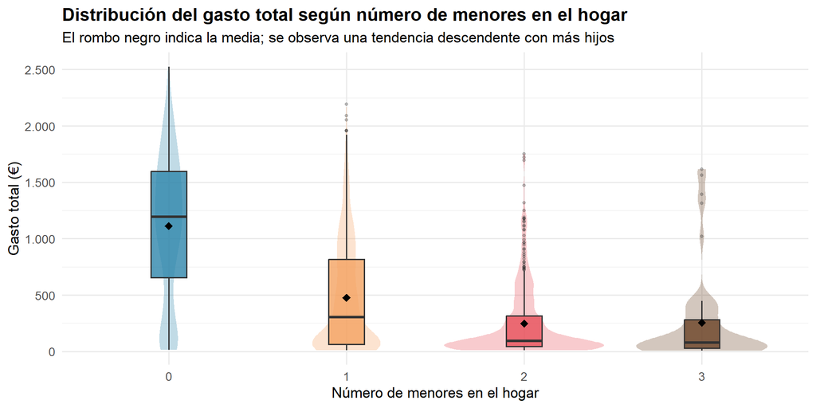

```r
ggplot(data, aes(x = Children_Home, y = Total_Spending, fill = Children_Home)) +
    geom_violin(alpha = 0.3, color = NA) +
    geom_boxplot(width = 0.2, alpha = 0.8, outlier.alpha = 0.3, outlier.size = 1) +
    stat_summary(fun = mean, geom = "point", shape = 18, size = 3, color = "black") +
    scale_fill_manual(values = palette_children) +
    scale_y_continuous(labels = comma_format(big.mark = ".", decimal.mark = ",")) +
    labs(
        title = "Distribución del gasto total según número de menores en el hogar",
        subtitle = "El rombo negro indica la media; se observa una tendencia descendente con más hijos",
        x = "Número de menores en el hogar", y = "Gasto total (€)"
    ) +
    theme_minimal(base_size = 13) +
    theme(
        legend.position = "none",
        plot.title = element_text(face = "bold")
    )
```

### 3.2. Test de Kruskal-Wallis

El **test de Kruskal-Wallis** es la extensión no paramétrica del ANOVA y permite comparar más de dos grupos cuando no se asume normalidad.

```r
kruskal_children <- kruskal.test(Total_Spending ~ Children_Home, data = data)
kruskal_children
```

```
##
##  Kruskal-Wallis rank sum test
##
## data:  Total_Spending by Children_Home
## Kruskal-Wallis chi-squared = 550.99, df = 3, p-value < 2.2e-16
```

### 3.3. Comparaciones post-hoc: Test de Dunn

Si el test de Kruskal-Wallis resulta significativo, necesitamos saber *qué pares de grupos* difieren entre sí. Para ello aplicamos el **test de Dunn** con corrección de Bonferroni para controlar el error de tipo I por múltiples comparaciones.

```r
if (!requireNamespace("dunn.test", quietly = TRUE)) install.packages("dunn.test", repos = "https://cran.r-project.org/")
library(dunn.test)

dunn_result <- dunn.test(data$Total_Spending, data$Children_Home, method = "bonferroni")
```

```
##   Kruskal-Wallis rank sum test
##
## data: x and group
## Kruskal-Wallis chi-squared = 550.9926, df = 3, p-value = 0
##
##
##                    Dunn's Pairwise Comparison of x by group
##                                  (Bonferroni)
## Col Mean-│
## Row Mean │          0          1          2
## ─────────┼─────────────────────────────────
##        1 │   18.32491
##          │     0.0000*
##          │
##        2 │   21.15835   7.365190
##          │     0.0000*    0.0000*
##          │
##        3 │   9.856182   3.683051   0.726620
##          │     0.0000*    0.0007*    1.0000
##
## α = 0.05
## Reject Ho if p ≤ α/2, where p = Pr(Z ≥ |z|)
```

### 3.4. Gasto por categoría según número de hijos

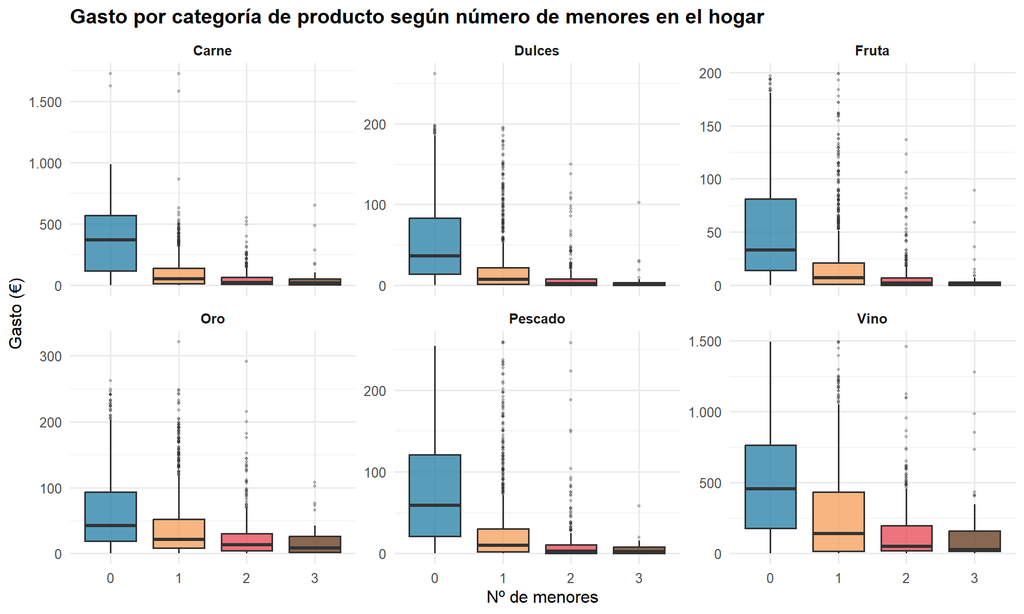

```r
gasto_nhijos <- data %>%
    select(
        Children_Home, MntWines, MntFruits, MntMeatProducts,
        MntFishProducts, MntSweetProducts, MntGoldProds
    ) %>%
    pivot_longer(-Children_Home, names_to = "Categoria", values_to = "Gasto") %>%
    mutate(Categoria = dplyr::recode(Categoria,
        "MntWines" = "Vino", "MntFruits" = "Fruta", "MntMeatProducts" = "Carne",
        "MntFishProducts" = "Pescado", "MntSweetProducts" = "Dulces", "MntGoldProds" = "Oro"
    ))

ggplot(gasto_nhijos, aes(x = Children_Home, y = Gasto, fill = Children_Home)) +
    geom_boxplot(alpha = 0.8, outlier.alpha = 0.3, outlier.size = 0.8) +
    scale_fill_manual(values = palette_children) +
    facet_wrap(~Categoria, scales = "free_y", ncol = 3) +
    scale_y_continuous(labels = comma_format(big.mark = ".", decimal.mark = ",")) +
    labs(
        title = "Gasto por categoría de producto según número de menores en el hogar",
        x = "Nº de menores", y = "Gasto (€)"
    ) +
    theme_minimal(base_size = 12) +
    theme(
        legend.position = "none",
        plot.title = element_text(face = "bold"),
        strip.text = element_text(face = "bold")
    )
```

## Análisis 4: Correlaciones entre estructura familiar y gasto

### 4.1. Matriz de correlaciones de Spearman

Utilizamos el **coeficiente de correlación de Spearman**, que mide la asociación monotónica entre variables y es adecuado cuando las distribuciones no son normales.

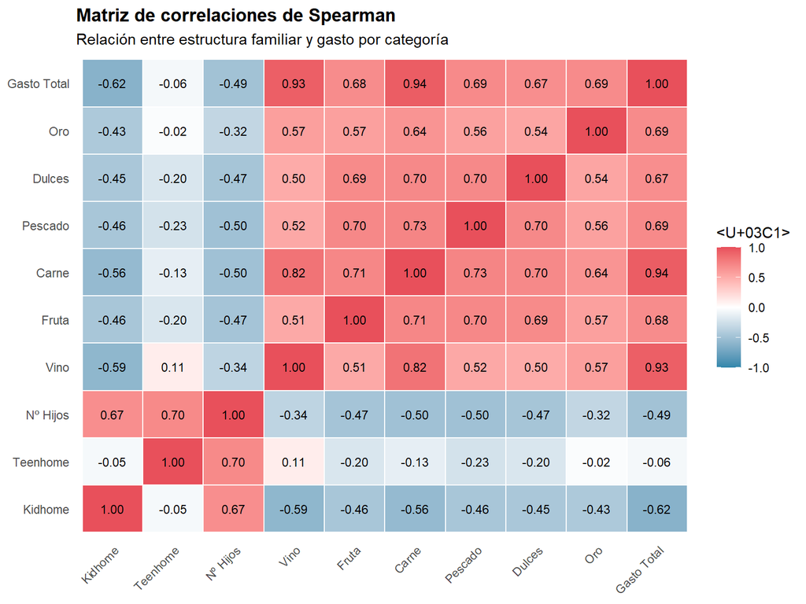

```r
vars_correlacion <- data %>%
    select(Kidhome, Teenhome,
        Children_Home_num = Children_Home,
        MntWines, MntFruits, MntMeatProducts,
        MntFishProducts, MntSweetProducts, MntGoldProds, Total_Spending
    ) %>%
    mutate(Children_Home_num = as.numeric(as.character(Children_Home_num)))

cor_matrix <- cor(vars_correlacion, method = "spearman")

# Visualización manual del heatmap
cor_df <- as.data.frame(as.table(cor_matrix))
names(cor_df) <- c("Var1", "Var2", "Correlacion")

# Renombrar variables para mejor legibilidad
niveles <- c(
    "Kidhome", "Teenhome", "Children_Home_num",
    "MntWines", "MntFruits", "MntMeatProducts",
    "MntFishProducts", "MntSweetProducts", "MntGoldProds", "Total_Spending"
)
etiquetas <- c(
    "Kidhome", "Teenhome", "Nº Hijos",
    "Vino", "Fruta", "Carne",
    "Pescado", "Dulces", "Oro", "Gasto Total"
)

cor_df$Var1 <- factor(cor_df$Var1, levels = niveles, labels = etiquetas)
cor_df$Var2 <- factor(cor_df$Var2, levels = niveles, labels = etiquetas)

ggplot(cor_df, aes(x = Var1, y = Var2, fill = Correlacion)) +
    geom_tile(color = "white", linewidth = 0.5) +
    geom_text(aes(label = sprintf("%.2f", Correlacion)), size = 3) +
    scale_fill_gradient2(
        low = "#2E86AB", mid = "white", high = "#E8505B",
        midpoint = 0, limits = c(-1, 1)
    ) +
    labs(
        title = "Matriz de correlaciones de Spearman",
        subtitle = "Relación entre estructura familiar y gasto por categoría",
        x = NULL, y = NULL, fill = "ρ"
    ) +
    theme_minimal(base_size = 11) +
    theme(
        axis.text.x = element_text(angle = 45, hjust = 1),
        plot.title = element_text(face = "bold"),
        panel.grid = element_blank()
    )
```

### 4.2. Significancia de las correlaciones clave

```r
vars_familia <- c("Kidhome", "Teenhome")
vars_gasto <- c(
    "MntWines", "MntFruits", "MntMeatProducts",
    "MntFishProducts", "MntSweetProducts", "MntGoldProds", "Total_Spending"
)

resultados_cor <- expand.grid(
    Familia = vars_familia, Gasto = vars_gasto,
    stringsAsFactors = FALSE
)
resultados_cor$rho <- NA
resultados_cor$p_valor <- NA

for (i in seq_len(nrow(resultados_cor))) {
    test <- suppressWarnings(
        cor.test(
            as.numeric(as.character(data[[resultados_cor$Familia[i]]])),
            data[[resultados_cor$Gasto[i]]],
            method = "spearman",
            exact = FALSE
        )
    )
    resultados_cor$rho[i] <- round(test$estimate, 3)
    resultados_cor$p_valor[i] <- test$p.value
}

resultados_cor$Significativo <- ifelse(resultados_cor$p_valor < 0.05, "Sí", "No")

print(resultados_cor)
```

```
##     Familia            Gasto    rho       p_valor Significativo
## 1   Kidhome         MntWines -0.585 1.864455e-202            Sí
## 2  Teenhome         MntWines  0.109  3.143417e-07            Sí
## 3   Kidhome        MntFruits -0.456 2.841885e-113            Sí
## 4  Teenhome        MntFruits -0.202  1.241794e-21            Sí
## 5   Kidhome  MntMeatProducts -0.555 1.835300e-178            Sí
## 6  Teenhome  MntMeatProducts -0.130  8.056969e-10            Sí
## 7   Kidhome  MntFishProducts -0.456 9.026537e-114            Sí
## 8  Teenhome  MntFishProducts -0.234  9.882935e-29            Sí
## 9   Kidhome MntSweetProducts -0.447 1.729515e-108            Sí
## 10 Teenhome MntSweetProducts -0.201  1.354040e-21            Sí
## 11  Kidhome     MntGoldProds -0.430 9.053533e-100            Sí
## 12 Teenhome     MntGoldProds -0.024  2.629448e-01            No
## 13  Kidhome   Total_Spending -0.621 1.458756e-234            Sí
## 14 Teenhome   Total_Spending -0.058  6.305997e-03            Sí
```

## Análisis 5: Estado civil y patrón de consumo

### 5.1. Gasto total por estado civil

```r
data %>%
    group_by(Marital_Status) %>%
    summarise(
        n = n(),
        media = mean(Total_Spending),
        mediana = median(Total_Spending),
        desv_tip = sd(Total_Spending),
        .groups = "drop"
    )
```

```
## # A tibble: 5 x 5
##   Marital_Status     n media mediana desv_tip
##   <fct>          <int> <dbl>   <dbl>    <dbl>
## 1 Single           471  614.    369      631.
## 2 Together         572  607.    394.     609.
## 3 Married          855  593.    397      591.
## 4 Divorced         228  621.    431      580.
## 5 Widow             76  728.    626.     577.
```

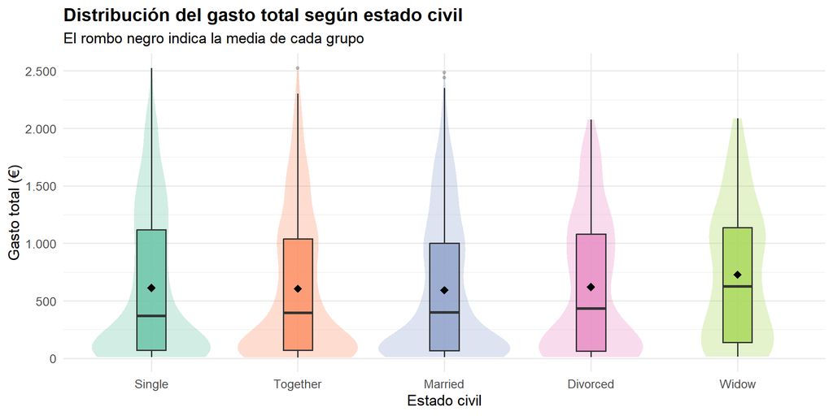

```r
ggplot(data, aes(x = Marital_Status, y = Total_Spending, fill = Marital_Status)) +
    geom_violin(alpha = 0.3, color = NA) +
    geom_boxplot(width = 0.2, alpha = 0.8, outlier.alpha = 0.3, outlier.size = 1) +
    stat_summary(fun = mean, geom = "point", shape = 18, size = 3, color = "black") +
    scale_fill_brewer(palette = "Set2") +
    scale_y_continuous(labels = comma_format(big.mark = ".", decimal.mark = ",")) +
    labs(
        title = "Distribución del gasto total según estado civil",
        subtitle = "El rombo negro indica la media de cada grupo",
        x = "Estado civil", y = "Gasto total (€)"
    ) +
    theme_minimal(base_size = 13) +
    theme(
        legend.position = "none",
        plot.title = element_text(face = "bold")
    )
```

### 5.2. Test de Kruskal-Wallis

```r
kruskal_marital <- kruskal.test(Total_Spending ~ Marital_Status, data = data)
kruskal_marital
```

```
##
##  Kruskal-Wallis rank sum test
##
## data:  Total_Spending by Marital_Status
## Kruskal-Wallis chi-squared = 5.2075, df = 4, p-value = 0.2667
```

### 5.3. Comparaciones post-hoc por estado civil

```r
dunn_marital <- dunn.test(data$Total_Spending, data$Marital_Status, method = "bonferroni")
```

```
##   Kruskal-Wallis rank sum test
##
## data: x and group
## Kruskal-Wallis chi-squared = 5.2075, df = 4, p-value = 0.27
##
##
##                    Dunn's Pairwise Comparison of x by group
##                                  (Bonferroni)
## Col Mean-│
## Row Mean │   Divorced    Married     Single   Together
## ─────────┼────────────────────────────────────────────
##  Married │   0.455662
##          │     1.0000
##          │
##   Single │   0.336044  -0.119397
##          │     1.0000     1.0000
##          │
## Together │   0.369944  -0.092350   0.029938
##          │     1.0000     1.0000     1.0000
##          │
##    Widow │  -1.763096  -2.234724  -2.108453  -2.150059
##          │     0.3894     0.1272     0.1750     0.1578
##
## α = 0.05
## Reject Ho if p ≤ α/2, where p = Pr(Z ≥ |z|)
```

### 5.4. Perfil de gasto por categoría y estado civil

```r
gasto_marital <- data %>%
    group_by(Marital_Status) %>%
    summarise(
        Vino = mean(MntWines),
        Fruta = mean(MntFruits),
        Carne = mean(MntMeatProducts),
        Pescado = mean(MntFishProducts),
        Dulces = mean(MntSweetProducts),
        Oro = mean(MntGoldProds),
        .groups = "drop"
    ) %>%
    pivot_longer(-Marital_Status, names_to = "Categoria", values_to = "Gasto_Medio")

p <- ggplot(gasto_marital, aes(x = Marital_Status, y = Gasto_Medio, fill = Categoria)) +
    geom_col(position = "fill", width = 0.7, alpha = 0.9) +
    scale_fill_manual(values = palette_products) +
    scale_y_continuous(labels = percent_format()) +
    labs(
        title = "Distribución proporcional del gasto por estado civil",
        x = "Estado civil", y = "Proporción del gasto",
        fill = "Categoría"
    ) +
    theme_minimal(base_size = 13) +
    theme(plot.title = element_text(face = "bold"))

ggplotly(p)
```

[interactive chart not shown]

## Análisis 6 : Modelo predictivo — Árbol de decisión

Para ir más allá del análisis descriptivo y los tests estadísticos, construimos un **árbol de decisión** que predice el nivel de gasto (`Total_Spending`) a partir de las variables de estructura familiar. Este modelo permite identificar qué variables son las más determinantes y qué combinaciones de características definen los distintos perfiles de gasto.

```r
data_modelo <- data %>%
    mutate(Children_Home_num = as.numeric(as.character(Children_Home))) %>%
    select(Total_Spending, Income, Kidhome, Teenhome, Children_Home_num, Marital_Status)

set.seed(42)
tree_model <- rpart(Total_Spending ~ .,
    data = data_modelo,
    control = rpart.control(cp = 0.01, maxdepth = 4, minsplit = 50)
)
```

### 6.1. Visualización del árbol

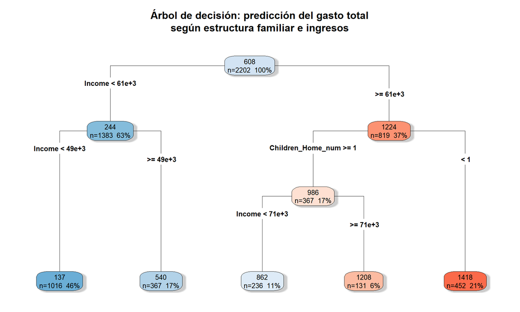

```r
rpart.plot(tree_model,
    type = 4,
    extra = 101,
    fallen.leaves = TRUE,
    shadow.col = "gray80",
    box.palette = "BuRd",
    main = "Árbol de decisión: predicción del gasto total\nsegún estructura familiar e ingresos",
    cex = 0.8
)
```

### 6.2. Importancia de las variables

```r
importancia <- tree_model$variable.importance
importancia_df <- data.frame(
    Variable = names(importancia),
    Importancia = as.numeric(importancia)
) %>%
    arrange(desc(Importancia)) %>%
    mutate(Importancia_Rel = Importancia / sum(Importancia) * 100)

importancia_df
```

```
##            Variable Importancia Importancia_Rel
## 1            Income   562077961      59.9065130
## 2 Children_Home_num   206477624      22.0064748
## 3           Kidhome   133796398      14.2600782
## 4          Teenhome    34358839       3.6619799
## 5    Marital_Status     1547695       0.1649541
```

```r
p_importancia <- ggplot(importancia_df, aes(x = reorder(Variable, Importancia_Rel), y = Importancia_Rel,
                                           text = paste0("Variable: ", Variable,
                                                         "<br>Importancia: ", round(Importancia_Rel, 1), "%"))) +
    geom_col(fill = "#2E86AB", alpha = 0.9, width = 0.6) +
    geom_text(aes(label = paste0(round(Importancia_Rel, 1), "%")),
        hjust = -0.2, size = 4
    ) +
    coord_flip() +
    scale_y_continuous(expand = expansion(mult = c(0, 0.15))) +
    labs(
        title = "Importancia relativa de las variables en el modelo (interactivo)",
        subtitle = "Contribución de cada variable a la predicción del gasto total",
        x = NULL, y = "Importancia relativa (%)"
    ) +
    theme_minimal(base_size = 13) +
    theme(plot.title = element_text(face = "bold"))

ggplotly(p_importancia, tooltip = "text")
```

[interactive chart not shown]

### 6.3. Evaluación del modelo

```r
predicciones <- predict(tree_model, data_modelo)
r2 <- cor(data_modelo$Total_Spending, predicciones)^2
rmse <- sqrt(mean((data_modelo$Total_Spending - predicciones)^2))

cat("R² del modelo:", round(r2, 4), "\n")
```

```
## R² del modelo: 0.7333
```

```r
cat("RMSE:", round(rmse, 2), "€\n")
```

```
## RMSE: 311.24 €
```

```r
cat("Gasto medio real:", round(mean(data_modelo$Total_Spending), 2), "€\n")
```

```
## Gasto medio real: 608.49 €
```

```r
cat("Error relativo (RMSE / media):", round(rmse / mean(data_modelo$Total_Spending) * 100, 1), "%\n")
```

```
## Error relativo (RMSE / media): 51.1 %
```

## Conclusiones

Tras el análisis realizado mediante tests no paramétricos, correlaciones y un modelo de árbol de decisión, podemos extraer las siguientes conclusiones:

**1. La presencia de hijos está significativamente asociada a un menor gasto total.** El test de Wilcoxon confirma que los hogares sin hijos presentan un gasto total significativamente superior a los hogares con hijos. Esta diferencia no se debe al azar, sino a un patrón consistente y de magnitud relevante.

**2. El impacto no es uniforme entre categorías de producto.** Las categorías más afectadas por la presencia de hijos son el vino y la carne, que son también las de mayor gasto medio. Esto sugiere que los hogares con menores redistribuyen su presupuesto reduciendo las partidas asociadas a productos más selectos o de mayor coste unitario.

### Implicaciones empresariales tácticas

Desde una perspectiva de *Customer Analytics* aplicada al impacto directo en negocio y ROI de la compañía, estas evidencias exigen reorientar la ejecución del marketing:

- **Segmentación Golden:** Los hogares sin hijos con ingresos medios-altos (nuestro segmento Pareto) deben absorber el presupuesto premium de captación y retención. El catálogo de alto margen (carnes maduradas, bodegas especiales) es altamente susceptible de cruces con estas siluetas sociodemográficas.
- **Rotación en Familias:** La merma de capacidad predictiva de ingresos en el bloque de familias obliga a pivotar las campañas en este clúster hacia los *basics*. A nivel de negocio, es imperativo rediseñar *packs de volumen* (compras conjuntas) para inyectar liquidez y fidelidad a este nicho.

## 7. Reflexión estratégica del modelo de negocio

Los patrones observados (dominio del vino o mayor gasto en clientes sin hijos con rentas altas) sugieren que la empresa opera en el sector de distribución de productos alimentarios y de bebidas premium, cuyo cliente prototipo es el consumidor urbano adulto sin cargas familiares. Las familias con hijos no son un segmento principal de esta plataforma: sus hábitos de consumo (cocina en casa, compra en supermercados, mayor precio-sensibilidad) las alejan estructuralmente del perfil de comprador habitual.

## Referencias

STHDA. “Correlation Test between Two Variables in R: Pearson, Spearman, and Kendall”. Recuperado de: http://www.sthda.com/english/wiki/correlation-test-between-two-variables-in-r

UC Business Analytics. “Regression Trees and Recursive Partitioning in R”. Recuperado de: https://uc-r.github.io/regression_trees

R for Data Science. “Data Transformation: dplyr and data manipulation”. Recuperado de: https://r4ds.hadley.nz/data-transform

R-bloggers. “Customer Analytics: Using Deep Learning With Keras To Predict Customer Churn”. Recuperado de: https://www.r-bloggers.com/2017/11/customer-analytics-using-deep-learning-with-keras-to-predict-customer-churn/